Welcome to the Investigate a Dataset project!

# Project: Investigate a Dataset (tmdb-movies)

- Introduction
- Data Wrangling
- Exploratory Data Analysis
- Conclusions

## Introduction

This data set contains information about 10,000 movies collected from The Movie Database (TMDb)  
Questions must answer  
1-Which genres are most popular from year to year?  
2-What kinds of properties are associated with movies that have high revenues?

```python
# import statements for all of the packages
import numpy as np
import pandas as pd
import matplotlib.pyplot as plt
%matplotlib inline
import seaborn as sns
```

## Data Wrangling

In this section of the report, i will load in the data, check for cleanliness, and then trim and clean your dataset for analysis.

### General Properties

```python
# Load your data and print out a few lines.
df=pd.read_csv('tmdb-movies.csv')
df.head()
```

|  | id | imdb_id | popularity | budget | revenue | original_title | cast | homepage | director | tagline | ... | overview | runtime | genres | production_companies | release_date | vote_count | vote_average | release_year | budget_adj | revenue_adj |
| --- | --- | --- | --- | --- | --- | --- | --- | --- | --- | --- | --- | --- | --- | --- | --- | --- | --- | --- | --- | --- | --- |
| 0 | 135397 | tt0369610 | 32.985763 | 150000000 | 1513528810 | Jurassic World | Chris Pratt\|Bryce Dallas Howard\|Irrfan Khan\|Vi... | http://www.jurassicworld.com/ | Colin Trevorrow | The park is open. | ... | Twenty-two years after the events of Jurassic ... | 124 | Action\|Adventure\|Science Fiction\|Thriller | Universal Studios\|Amblin Entertainment\|Legenda... | 6/9/15 | 5562 | 6.5 | 2015 | 1.379999e+08 | 1.392446e+09 |
| 1 | 76341 | tt1392190 | 28.419936 | 150000000 | 378436354 | Mad Max: Fury Road | Tom Hardy\|Charlize Theron\|Hugh Keays-Byrne\|Nic... | http://www.madmaxmovie.com/ | George Miller | What a Lovely Day. | ... | An apocalyptic story set in the furthest reach... | 120 | Action\|Adventure\|Science Fiction\|Thriller | Village Roadshow Pictures\|Kennedy Miller Produ... | 5/13/15 | 6185 | 7.1 | 2015 | 1.379999e+08 | 3.481613e+08 |
| 2 | 262500 | tt2908446 | 13.112507 | 110000000 | 295238201 | Insurgent | Shailene Woodley\|Theo James\|Kate Winslet\|Ansel... | http://www.thedivergentseries.movie/#insurgent | Robert Schwentke | One Choice Can Destroy You | ... | Beatrice Prior must confront her inner demons ... | 119 | Adventure\|Science Fiction\|Thriller | Summit Entertainment\|Mandeville Films\|Red Wago... | 3/18/15 | 2480 | 6.3 | 2015 | 1.012000e+08 | 2.716190e+08 |
| 3 | 140607 | tt2488496 | 11.173104 | 200000000 | 2068178225 | Star Wars: The Force Awakens | Harrison Ford\|Mark Hamill\|Carrie Fisher\|Adam D... | http://www.starwars.com/films/star-wars-episod... | J.J. Abrams | Every generation has a story. | ... | Thirty years after defeating the Galactic Empi... | 136 | Action\|Adventure\|Science Fiction\|Fantasy | Lucasfilm\|Truenorth Productions\|Bad Robot | 12/15/15 | 5292 | 7.5 | 2015 | 1.839999e+08 | 1.902723e+09 |
| 4 | 168259 | tt2820852 | 9.335014 | 190000000 | 1506249360 | Furious 7 | Vin Diesel\|Paul Walker\|Jason Statham\|Michelle ... | http://www.furious7.com/ | James Wan | Vengeance Hits Home | ... | Deckard Shaw seeks revenge against Dominic Tor... | 137 | Action\|Crime\|Thriller | Universal Pictures\|Original Film\|Media Rights ... | 4/1/15 | 2947 | 7.3 | 2015 | 1.747999e+08 | 1.385749e+09 |

5 rows × 21 columns

###### Name of the columns in this dataset.

```python
df.columns
```

```
Index(['id', 'imdb_id', 'popularity', 'budget', 'revenue', 'original_title',
       'cast', 'homepage', 'director', 'tagline', 'keywords', 'overview',
       'runtime', 'genres', 'production_companies', 'release_date',
       'vote_count', 'vote_average', 'release_year', 'budget_adj',
       'revenue_adj'],
      dtype='object')
```

#### Description columns name and content

1-popularity :The MOVIEmeter rank of a film is a measure of popularity. It is essentially based on page views of pages related to a film. ex 2,376,452 IMDb users have given a weighted average vote of 9.3 / 10  
2- run time : Runtime is the time between the starting of the movie upto the end of the credits scene. It does not include any trailers and break  
3- tagline : is a short, memorable phrase used in marketing campaigns to convey the value of a brand or its products.  
4- vote_count: number of people who vote in imdb

```python
df.info()
```

```
<class 'pandas.core.frame.DataFrame'>
RangeIndex: 10866 entries, 0 to 10865
Data columns (total 21 columns):
 #   Column                Non-Null Count  Dtype
---  ------                --------------  -----
 0   id                    10866 non-null  int64
 1   imdb_id               10856 non-null  object
 2   popularity            10866 non-null  float64
 3   budget                10866 non-null  int64
 4   revenue               10866 non-null  int64
 5   original_title        10866 non-null  object
 6   cast                  10790 non-null  object
 7   homepage              2936 non-null   object
 8   director              10822 non-null  object
 9   tagline               8042 non-null   object
 10  keywords              9373 non-null   object
 11  overview              10862 non-null  object
 12  runtime               10866 non-null  int64
 13  genres                10843 non-null  object
 14  production_companies  9836 non-null   object
 15  release_date          10866 non-null  object
 16  vote_count            10866 non-null  int64
 17  vote_average          10866 non-null  float64
 18  release_year          10866 non-null  int64
 19  budget_adj            10866 non-null  float64
 20  revenue_adj           10866 non-null  float64
dtypes: float64(4), int64(6), object(11)
memory usage: 1.7+ MB
```

###### Data type and dimenions

```python
df.shape
```

```
(10866, 21)
```

consists of 10866 rows and 21 columns.

```python
df.dtypes
```

```
id                        int64
imdb_id                  object
popularity              float64
budget                    int64
revenue                   int64
original_title           object
cast                     object
homepage                 object
director                 object
tagline                  object
keywords                 object
overview                 object
runtime                   int64
genres                   object
production_companies     object
release_date             object
vote_count                int64
vote_average            float64
release_year              int64
budget_adj              float64
revenue_adj             float64
dtype: object
```

###### basic descriptive statistics

```python
df.describe()
```

|  | id | popularity | budget | revenue | runtime | vote_count | vote_average | release_year | budget_adj | revenue_adj |
| --- | --- | --- | --- | --- | --- | --- | --- | --- | --- | --- |
| count | 10866.000000 | 10866.000000 | 1.086600e+04 | 1.086600e+04 | 10866.000000 | 10866.000000 | 10866.000000 | 10866.000000 | 1.086600e+04 | 1.086600e+04 |
| mean | 66064.177434 | 0.646441 | 1.462570e+07 | 3.982332e+07 | 102.070863 | 217.389748 | 5.974922 | 2001.322658 | 1.755104e+07 | 5.136436e+07 |
| std | 92130.136561 | 1.000185 | 3.091321e+07 | 1.170035e+08 | 31.381405 | 575.619058 | 0.935142 | 12.812941 | 3.430616e+07 | 1.446325e+08 |
| min | 5.000000 | 0.000065 | 0.000000e+00 | 0.000000e+00 | 0.000000 | 10.000000 | 1.500000 | 1960.000000 | 0.000000e+00 | 0.000000e+00 |
| 25% | 10596.250000 | 0.207583 | 0.000000e+00 | 0.000000e+00 | 90.000000 | 17.000000 | 5.400000 | 1995.000000 | 0.000000e+00 | 0.000000e+00 |
| 50% | 20669.000000 | 0.383856 | 0.000000e+00 | 0.000000e+00 | 99.000000 | 38.000000 | 6.000000 | 2006.000000 | 0.000000e+00 | 0.000000e+00 |
| 75% | 75610.000000 | 0.713817 | 1.500000e+07 | 2.400000e+07 | 111.000000 | 145.750000 | 6.600000 | 2011.000000 | 2.085325e+07 | 3.369710e+07 |
| max | 417859.000000 | 32.985763 | 4.250000e+08 | 2.781506e+09 | 900.000000 | 9767.000000 | 9.200000 | 2015.000000 | 4.250000e+08 | 2.827124e+09 |

##### From first look at data

1- there are nan and 0 value in columns  
2- the columns like run_time and revenue and budget don`t contain any unit so I will take Doller and minute to unite  
3- there are un necessary columns for our analysis imdb_id,homepage, keywords, overview,run time and more we need to delete them  
4- there are columns contain several values, which are seperated by "|" like cast ,director,genres,production_companie we need to clean it

### Data Cleaning

After discussing the structure of the data and any problems that need to be cleaned, perform those cleaning steps in the second part of this section.

###### Deal with 0 and nan value

```python
#list of this columns
drop_list = ['budget','revenue','runtime','budget_adj','revenue_adj']
#replace "0" with nan
df[drop_list] = df[drop_list].replace(0,np.NAN)
#drop nan
df.dropna(subset= drop_list  ,inplace = True)
```

```python
#test
df.budget.value_counts()
df.revenue.value_counts()
df.runtime.value_counts()
df['budget_adj'].value_counts()
```

```
2.103337e+07    14
3.349690e+07    14
2.000000e+07    13
2.025573e+07    11
2.629171e+07    11
                ..
2.386885e+07     1
4.647239e+05     1
1.473348e+07     1
6.398027e+06     1
3.000000e+00     1
Name: budget_adj, Length: 2096, dtype: int64
```

```python
df.describe()
```

|  | id | popularity | budget | revenue | runtime | vote_count | vote_average | release_year | budget_adj | revenue_adj |
| --- | --- | --- | --- | --- | --- | --- | --- | --- | --- | --- |
| count | 3855.000000 | 3855.000000 | 3.855000e+03 | 3.855000e+03 | 3855.000000 | 3855.000000 | 3855.00000 | 3855.000000 | 3.855000e+03 | 3.855000e+03 |
| mean | 39888.783398 | 1.191400 | 3.720183e+07 | 1.076589e+08 | 109.215824 | 527.611933 | 6.16786 | 2001.263294 | 4.423630e+07 | 1.370294e+08 |
| std | 67213.815955 | 1.475002 | 4.220291e+07 | 1.765248e+08 | 19.922166 | 879.868374 | 0.79504 | 11.281989 | 4.480403e+07 | 2.160944e+08 |
| min | 5.000000 | 0.001117 | 1.000000e+00 | 2.000000e+00 | 15.000000 | 10.000000 | 2.20000 | 1960.000000 | 9.693980e-01 | 2.370705e+00 |
| 25% | 6074.000000 | 0.462448 | 1.000000e+07 | 1.357645e+07 | 95.000000 | 71.000000 | 5.70000 | 1995.000000 | 1.309053e+07 | 1.834123e+07 |
| 50% | 11322.000000 | 0.797298 | 2.400000e+07 | 4.479322e+07 | 106.000000 | 204.000000 | 6.20000 | 2004.000000 | 3.001558e+07 | 6.171861e+07 |
| 75% | 38577.000000 | 1.368245 | 5.000000e+07 | 1.241530e+08 | 119.000000 | 580.000000 | 6.70000 | 2010.000000 | 6.061307e+07 | 1.632401e+08 |
| max | 417859.000000 | 32.985763 | 4.250000e+08 | 2.781506e+09 | 338.000000 | 9767.000000 | 8.40000 | 2015.000000 | 4.250000e+08 | 2.827124e+09 |

```python
#change release_date to stander formate
```

```python
df['release_date'] =pd.to_datetime(df['release_date'])
#datetime64
```

```python
df.info()
```

```
<class 'pandas.core.frame.DataFrame'>
Int64Index: 3855 entries, 0 to 10848
Data columns (total 21 columns):
 #   Column                Non-Null Count  Dtype
---  ------                --------------  -----
 0   id                    3855 non-null   int64
 1   imdb_id               3855 non-null   object
 2   popularity            3855 non-null   float64
 3   budget                3855 non-null   float64
 4   revenue               3855 non-null   float64
 5   original_title        3855 non-null   object
 6   cast                  3851 non-null   object
 7   homepage              1426 non-null   object
 8   director              3854 non-null   object
 9   tagline               3575 non-null   object
 10  keywords              3717 non-null   object
 11  overview              3855 non-null   object
 12  runtime               3855 non-null   float64
 13  genres                3855 non-null   object
 14  production_companies  3809 non-null   object
 15  release_date          3855 non-null   datetime64[ns]
 16  vote_count            3855 non-null   int64
 17  vote_average          3855 non-null   float64
 18  release_year          3855 non-null   int64
 19  budget_adj            3855 non-null   float64
 20  revenue_adj           3855 non-null   float64
dtypes: datetime64[ns](1), float64(7), int64(3), object(10)
memory usage: 662.6+ KB
```

# spreate columns with servel value by split'|'

https://stackoverflow.com/questions/48207115/splitting-a-column-into-multiple-columns-with-specific-name-in-pandas-dataframe

```python
df=df.join(df['genres'].str.split( '|' , expand = True ).add_prefix('genres'))

df
```

|  | id | imdb_id | popularity | budget | revenue | original_title | cast | homepage | director | tagline | ... | vote_count | vote_average | release_year | budget_adj | revenue_adj | genres0 | genres1 | genres2 | genres3 | genres4 |
| --- | --- | --- | --- | --- | --- | --- | --- | --- | --- | --- | --- | --- | --- | --- | --- | --- | --- | --- | --- | --- | --- |
| 0 | 135397 | tt0369610 | 32.985763 | 150000000.0 | 1.513529e+09 | Jurassic World | Chris Pratt\|Bryce Dallas Howard\|Irrfan Khan\|Vi... | http://www.jurassicworld.com/ | Colin Trevorrow | The park is open. | ... | 5562 | 6.5 | 2015 | 1.379999e+08 | 1.392446e+09 | Action | Adventure | Science Fiction | Thriller | None |
| 1 | 76341 | tt1392190 | 28.419936 | 150000000.0 | 3.784364e+08 | Mad Max: Fury Road | Tom Hardy\|Charlize Theron\|Hugh Keays-Byrne\|Nic... | http://www.madmaxmovie.com/ | George Miller | What a Lovely Day. | ... | 6185 | 7.1 | 2015 | 1.379999e+08 | 3.481613e+08 | Action | Adventure | Science Fiction | Thriller | None |
| 2 | 262500 | tt2908446 | 13.112507 | 110000000.0 | 2.952382e+08 | Insurgent | Shailene Woodley\|Theo James\|Kate Winslet\|Ansel... | http://www.thedivergentseries.movie/#insurgent | Robert Schwentke | One Choice Can Destroy You | ... | 2480 | 6.3 | 2015 | 1.012000e+08 | 2.716190e+08 | Adventure | Science Fiction | Thriller | None | None |
| 3 | 140607 | tt2488496 | 11.173104 | 200000000.0 | 2.068178e+09 | Star Wars: The Force Awakens | Harrison Ford\|Mark Hamill\|Carrie Fisher\|Adam D... | http://www.starwars.com/films/star-wars-episod... | J.J. Abrams | Every generation has a story. | ... | 5292 | 7.5 | 2015 | 1.839999e+08 | 1.902723e+09 | Action | Adventure | Science Fiction | Fantasy | None |
| 4 | 168259 | tt2820852 | 9.335014 | 190000000.0 | 1.506249e+09 | Furious 7 | Vin Diesel\|Paul Walker\|Jason Statham\|Michelle ... | http://www.furious7.com/ | James Wan | Vengeance Hits Home | ... | 2947 | 7.3 | 2015 | 1.747999e+08 | 1.385749e+09 | Action | Crime | Thriller | None | None |
| ... | ... | ... | ... | ... | ... | ... | ... | ... | ... | ... | ... | ... | ... | ... | ... | ... | ... | ... | ... | ... | ... |
| 10822 | 396 | tt0061184 | 0.670274 | 7500000.0 | 3.373669e+07 | Who's Afraid of Virginia Woolf? | Elizabeth Taylor\|Richard Burton\|George Segal\|S... | NaN | Mike Nichols | You are cordially invited to George and Martha... | ... | 74 | 7.5 | 1966 | 5.038511e+07 | 2.266436e+08 | Drama | None | None | None | None |
| 10828 | 5780 | tt0061107 | 0.402730 | 3000000.0 | 1.300000e+07 | Torn Curtain | Paul Newman\|Julie Andrews\|Lila Kedrova\|HansjÃ¶... | NaN | Alfred Hitchcock | It tears you apart with suspense! | ... | 46 | 6.3 | 1966 | 2.015404e+07 | 8.733419e+07 | Mystery | Thriller | None | None | None |
| 10829 | 6644 | tt0061619 | 0.395668 | 4653000.0 | 6.000000e+06 | El Dorado | John Wayne\|Robert Mitchum\|James Caan\|Charlene ... | NaN | Howard Hawks | It's the Big One with the Big Two | ... | 36 | 6.9 | 1966 | 3.125892e+07 | 4.030809e+07 | Action | Western | None | None | None |
| 10835 | 5923 | tt0060934 | 0.299911 | 12000000.0 | 2.000000e+07 | The Sand Pebbles | Steve McQueen\|Richard Attenborough\|Richard Cre... | NaN | Robert Wise | This is the heroic story of the men on the U.S... | ... | 28 | 7.0 | 1966 | 8.061618e+07 | 1.343603e+08 | Action | Adventure | Drama | War | Romance |
| 10848 | 2161 | tt0060397 | 0.207257 | 5115000.0 | 1.200000e+07 | Fantastic Voyage | Stephen Boyd\|Raquel Welch\|Edmond O'Brien\|Donal... | NaN | Richard Fleischer | A Fantastic and Spectacular Voyage... Through ... | ... | 42 | 6.7 | 1966 | 3.436265e+07 | 8.061618e+07 | Adventure | Science Fiction | None | None | None |

3855 rows × 26 columns

```python
df=df.join(df['cast'].str.split('|',expand = True).add_prefix('cast'))
df=df.join(df['director'].str.split('|',expand =True).add_prefix('director'))
df
```

|  | id | imdb_id | popularity | budget | revenue | original_title | cast | homepage | director | tagline | ... | director2 | director3 | director4 | director5 | director6 | director7 | director8 | director9 | director10 | director11 |
| --- | --- | --- | --- | --- | --- | --- | --- | --- | --- | --- | --- | --- | --- | --- | --- | --- | --- | --- | --- | --- | --- |
| 0 | 135397 | tt0369610 | 32.985763 | 150000000.0 | 1.513529e+09 | Jurassic World | Chris Pratt\|Bryce Dallas Howard\|Irrfan Khan\|Vi... | http://www.jurassicworld.com/ | Colin Trevorrow | The park is open. | ... | None | None | None | None | None | None | None | None | None | None |
| 1 | 76341 | tt1392190 | 28.419936 | 150000000.0 | 3.784364e+08 | Mad Max: Fury Road | Tom Hardy\|Charlize Theron\|Hugh Keays-Byrne\|Nic... | http://www.madmaxmovie.com/ | George Miller | What a Lovely Day. | ... | None | None | None | None | None | None | None | None | None | None |
| 2 | 262500 | tt2908446 | 13.112507 | 110000000.0 | 2.952382e+08 | Insurgent | Shailene Woodley\|Theo James\|Kate Winslet\|Ansel... | http://www.thedivergentseries.movie/#insurgent | Robert Schwentke | One Choice Can Destroy You | ... | None | None | None | None | None | None | None | None | None | None |
| 3 | 140607 | tt2488496 | 11.173104 | 200000000.0 | 2.068178e+09 | Star Wars: The Force Awakens | Harrison Ford\|Mark Hamill\|Carrie Fisher\|Adam D... | http://www.starwars.com/films/star-wars-episod... | J.J. Abrams | Every generation has a story. | ... | None | None | None | None | None | None | None | None | None | None |
| 4 | 168259 | tt2820852 | 9.335014 | 190000000.0 | 1.506249e+09 | Furious 7 | Vin Diesel\|Paul Walker\|Jason Statham\|Michelle ... | http://www.furious7.com/ | James Wan | Vengeance Hits Home | ... | None | None | None | None | None | None | None | None | None | None |
| ... | ... | ... | ... | ... | ... | ... | ... | ... | ... | ... | ... | ... | ... | ... | ... | ... | ... | ... | ... | ... | ... |
| 10822 | 396 | tt0061184 | 0.670274 | 7500000.0 | 3.373669e+07 | Who's Afraid of Virginia Woolf? | Elizabeth Taylor\|Richard Burton\|George Segal\|S... | NaN | Mike Nichols | You are cordially invited to George and Martha... | ... | None | None | None | None | None | None | None | None | None | None |
| 10828 | 5780 | tt0061107 | 0.402730 | 3000000.0 | 1.300000e+07 | Torn Curtain | Paul Newman\|Julie Andrews\|Lila Kedrova\|HansjÃ¶... | NaN | Alfred Hitchcock | It tears you apart with suspense! | ... | None | None | None | None | None | None | None | None | None | None |
| 10829 | 6644 | tt0061619 | 0.395668 | 4653000.0 | 6.000000e+06 | El Dorado | John Wayne\|Robert Mitchum\|James Caan\|Charlene ... | NaN | Howard Hawks | It's the Big One with the Big Two | ... | None | None | None | None | None | None | None | None | None | None |
| 10835 | 5923 | tt0060934 | 0.299911 | 12000000.0 | 2.000000e+07 | The Sand Pebbles | Steve McQueen\|Richard Attenborough\|Richard Cre... | NaN | Robert Wise | This is the heroic story of the men on the U.S... | ... | None | None | None | None | None | None | None | None | None | None |
| 10848 | 2161 | tt0060397 | 0.207257 | 5115000.0 | 1.200000e+07 | Fantastic Voyage | Stephen Boyd\|Raquel Welch\|Edmond O'Brien\|Donal... | NaN | Richard Fleischer | A Fantastic and Spectacular Voyage... Through ... | ... | None | None | None | None | None | None | None | None | None | None |

3855 rows × 43 columns

###### now drop uncessery columns

```python
df=df.drop(['keywords','homepage','overview','imdb_id','tagline'],axis=1)
```

```python
df.columns
```

```
Index(['id', 'popularity', 'budget', 'revenue', 'original_title', 'cast',
       'director', 'runtime', 'genres', 'production_companies', 'release_date',
       'vote_count', 'vote_average', 'release_year', 'budget_adj',
       'revenue_adj', 'genres0', 'genres1', 'genres2', 'genres3', 'genres4',
       'cast0', 'cast1', 'cast2', 'cast3', 'cast4', 'director0', 'director1',
       'director2', 'director3', 'director4', 'director5', 'director6',
       'director7', 'director8', 'director9', 'director10', 'director11'],
      dtype='object')
```

###### Check if there is any duplicated columns

```python
sum(df.duplicated())
```

```
1
```

```python
df=df.drop(['director6','director7','director8','director9','director10','director11'],axis=1)
```

that mean there is duplicated in dataset so i will drop duplicated

```python
df.drop_duplicates(inplace =True)
```

```python
sum(df.duplicated())
```

```
0
```

that mean there is no duplicated in dataset

```python
df.columns
```

```
Index(['id', 'popularity', 'budget', 'revenue', 'original_title', 'cast',
       'director', 'runtime', 'genres', 'production_companies', 'release_date',
       'vote_count', 'vote_average', 'release_year', 'budget_adj',
       'revenue_adj', 'genres0', 'genres1', 'genres2', 'genres3', 'genres4',
       'cast0', 'cast1', 'cast2', 'cast3', 'cast4', 'director0', 'director1',
       'director2', 'director3', 'director4', 'director5'],
      dtype='object')
```

## Exploratory Data Analysis

> **Tip**: Now that you've trimmed and cleaned your data, you're ready to move on to exploration. Compute statistics and create visualizations with the goal of addressing the research questions that you posed in the Introduction section. It is recommended that you be systematic with your approach. Look at one variable at a time, and then follow it up by looking at relationships between variables.

### Research Question 1 (Which genres are most popular from year to year!)

```python
df.info()
```

```
<class 'pandas.core.frame.DataFrame'>
Int64Index: 3854 entries, 0 to 10848
Data columns (total 32 columns):
 #   Column                Non-Null Count  Dtype
---  ------                --------------  -----
 0   id                    3854 non-null   int64
 1   popularity            3854 non-null   float64
 2   budget                3854 non-null   float64
 3   revenue               3854 non-null   float64
 4   original_title        3854 non-null   object
 5   cast                  3850 non-null   object
 6   director              3853 non-null   object
 7   runtime               3854 non-null   float64
 8   genres                3854 non-null   object
 9   production_companies  3808 non-null   object
```

[output cut: 24 more lines]

```python
df2=df.copy()
df2
```

|  | id | popularity | budget | revenue | original_title | cast | director | runtime | genres | production_companies | ... | cast1 | cast2 | cast3 | cast4 | director0 | director1 | director2 | director3 | director4 | director5 |
| --- | --- | --- | --- | --- | --- | --- | --- | --- | --- | --- | --- | --- | --- | --- | --- | --- | --- | --- | --- | --- | --- |
| 0 | 135397 | 32.985763 | 150000000.0 | 1.513529e+09 | Jurassic World | Chris Pratt\|Bryce Dallas Howard\|Irrfan Khan\|Vi... | Colin Trevorrow | 124.0 | Action\|Adventure\|Science Fiction\|Thriller | Universal Studios\|Amblin Entertainment\|Legenda... | ... | Bryce Dallas Howard | Irrfan Khan | Vincent D'Onofrio | Nick Robinson | Colin Trevorrow | None | None | None | None | None |
| 1 | 76341 | 28.419936 | 150000000.0 | 3.784364e+08 | Mad Max: Fury Road | Tom Hardy\|Charlize Theron\|Hugh Keays-Byrne\|Nic... | George Miller | 120.0 | Action\|Adventure\|Science Fiction\|Thriller | Village Roadshow Pictures\|Kennedy Miller Produ... | ... | Charlize Theron | Hugh Keays-Byrne | Nicholas Hoult | Josh Helman | George Miller | None | None | None | None | None |
| 2 | 262500 | 13.112507 | 110000000.0 | 2.952382e+08 | Insurgent | Shailene Woodley\|Theo James\|Kate Winslet\|Ansel... | Robert Schwentke | 119.0 | Adventure\|Science Fiction\|Thriller | Summit Entertainment\|Mandeville Films\|Red Wago... | ... | Theo James | Kate Winslet | Ansel Elgort | Miles Teller | Robert Schwentke | None | None | None | None | None |
| 3 | 140607 | 11.173104 | 200000000.0 | 2.068178e+09 | Star Wars: The Force Awakens | Harrison Ford\|Mark Hamill\|Carrie Fisher\|Adam D... | J.J. Abrams | 136.0 | Action\|Adventure\|Science Fiction\|Fantasy | Lucasfilm\|Truenorth Productions\|Bad Robot | ... | Mark Hamill | Carrie Fisher | Adam Driver | Daisy Ridley | J.J. Abrams | None | None | None | None | None |
| 4 | 168259 | 9.335014 | 190000000.0 | 1.506249e+09 | Furious 7 | Vin Diesel\|Paul Walker\|Jason Statham\|Michelle ... | James Wan | 137.0 | Action\|Crime\|Thriller | Universal Pictures\|Original Film\|Media Rights ... | ... | Paul Walker | Jason Statham | Michelle Rodriguez | Dwayne Johnson | James Wan | None | None | None | None | None |
| ... | ... | ... | ... | ... | ... | ... | ... | ... | ... | ... | ... | ... | ... | ... | ... | ... | ... | ... | ... | ... | ... |
| 10822 | 396 | 0.670274 | 7500000.0 | 3.373669e+07 | Who's Afraid of Virginia Woolf? | Elizabeth Taylor\|Richard Burton\|George Segal\|S... | Mike Nichols | 131.0 | Drama | Chenault Productions | ... | Richard Burton | George Segal | Sandy Dennis | Agnes Flanagan | Mike Nichols | None | None | None | None | None |
| 10828 | 5780 | 0.402730 | 3000000.0 | 1.300000e+07 | Torn Curtain | Paul Newman\|Julie Andrews\|Lila Kedrova\|Hansjö... | Alfred Hitchcock | 128.0 | Mystery\|Thriller | Universal Pictures | ... | Julie Andrews | Lila Kedrova | Hansjörg Felmy | Tamara Toumanova | Alfred Hitchcock | None | None | None | None | None |
| 10829 | 6644 | 0.395668 | 4653000.0 | 6.000000e+06 | El Dorado | John Wayne\|Robert Mitchum\|James Caan\|Charlene ... | Howard Hawks | 120.0 | Action\|Western | Paramount Pictures\|Laurel Productions | ... | Robert Mitchum | James Caan | Charlene Holt | Paul Fix | Howard Hawks | None | None | None | None | None |
| 10835 | 5923 | 0.299911 | 12000000.0 | 2.000000e+07 | The Sand Pebbles | Steve McQueen\|Richard Attenborough\|Richard Cre... | Robert Wise | 182.0 | Action\|Adventure\|Drama\|War\|Romance | Twentieth Century Fox Film Corporation\|Solar P... | ... | Richard Attenborough | Richard Crenna | Candice Bergen | Emmanuelle Arsan | Robert Wise | None | None | None | None | None |
| 10848 | 2161 | 0.207257 | 5115000.0 | 1.200000e+07 | Fantastic Voyage | Stephen Boyd\|Raquel Welch\|Edmond O'Brien\|Donal... | Richard Fleischer | 100.0 | Adventure\|Science Fiction | Twentieth Century Fox Film Corporation | ... | Raquel Welch | Edmond O'Brien | Donald Pleasence | Arthur O'Connell | Richard Fleischer | None | None | None | None | None |

3854 rows × 32 columns

```python
#select genres columns and release_year
df_genres_dates=df2[['genres','release_year']]

df_genres_dates
```

|  | genres | release_year |
| --- | --- | --- |
| 0 | Action\|Adventure\|Science Fiction\|Thriller | 2015 |
| 1 | Action\|Adventure\|Science Fiction\|Thriller | 2015 |
| 2 | Adventure\|Science Fiction\|Thriller | 2015 |
| 3 | Action\|Adventure\|Science Fiction\|Fantasy | 2015 |
| 4 | Action\|Crime\|Thriller | 2015 |
| ... | ... | ... |
| 10822 | Drama | 1966 |
| 10828 | Mystery\|Thriller | 1966 |
| 10829 | Action\|Western | 1966 |
| 10835 | Action\|Adventure\|Drama\|War\|Romance | 1966 |
| 10848 | Adventure\|Science Fiction | 1966 |

3854 rows × 2 columns

```python
#  df_reapt= df_genres_dates.groupby(['release_year'])['genres0'].value_counts()
# df_reapt2= df_genres_dates.groupby(['release_year'])['genres1'].value_counts()
# df_reapt4= df_genres_dates.groupby(['release_year'])['genres3'].value_counts()
#  df_reapt3= df_genres_dates.groupby(['release_year'])['genres2'].value_counts()
#  df_reapt5= df_genres_dates.groupby(['release_year'])['genres4'].value_counts()
# df_reapt
#  df_reapt2 + df_reapt +df_reapt3 +df_reapt4 +df_reapt5
```

```python
#create  unique genres
date_set=set()
genres_set=set()
year_release = df_genres_dates['release_year'].drop_duplicates()
#to create unique year and put it into set
for y in year_release :
   date_set.add(y)
date_set
#to create unique genres and put it into set
for y in year_release :
    genres_dict ={}
    genres_year=df_genres_dates[df_genres_dates['release_year']== y]
    genres_year =  genres_year["genres"].values
    for item in genres_year :
        genres_place =item.split('|')
        for ge in genres_place:
            if ge not in genres_set:
                genres_set.add(ge)

df_countgenres_year =pd.DataFrame(index=date_set ,columns =genres_set)
#because we didn`t put  value in data  so it will be nan
# to replace nan with 0
df_countgenres_year[:] = 0
##create a dataframe  contains the sum of  genre for every year
for y in year_release :
    genres_dict ={}
    genres_year=df_genres_dates[df_genres_dates['release_year']== y]
    genres_year =  genres_year["genres"].values
    for item in genres_year :
        genres_place =item.split('|')
        for ge in genres_place:
            if ge not in genres_dict :
                genres_dict[ge]=1
            else :
    #add sum of generes to dict
                genres_dict[ge]= genres_dict[ge]+1

#creat dataframe from genres_dict


    df_dict_genres=pd.DataFrame(genres_dict ,index =[y])

    df_countgenres_year.loc[y,df_dict_genres.columns] = df_countgenres_year.loc[y,df_dict_genres.columns] + df_dict_genres.loc[y]

df_countgenres_year
# now to find most popular geners in years

most_pop_genre_year = pd.DataFrame([df_countgenres_year.astype(float).idxmax(axis = "columns").values,
                                          df_countgenres_year.apply( max, axis=1 ).values],
                                           columns = df_countgenres_year.index,
                                       index = ["type of genre", 'number of repited'])
most_pop_genre_year
#https://stackoverflow.com/questions/48719937/getting-typeerror-reduction-operation-argmax-not-allowed-for-this-dtype-when
```

|  | 1960 | 1961 | 1962 | 1963 | 1964 | 1965 | 1966 | 1967 | 1968 | 1969 | ... | 2006 | 2007 | 2008 | 2009 | 2010 | 2011 | 2012 | 2013 | 2014 | 2015 |
| --- | --- | --- | --- | --- | --- | --- | --- | --- | --- | --- | --- | --- | --- | --- | --- | --- | --- | --- | --- | --- | --- |
| type of genre | Drama | Drama | Drama | History | Drama | Drama | Drama | Drama | Drama | Western | ... | Drama | Drama | Drama | Drama | Drama | Drama | Drama | Drama | Drama | Drama |
| number of repited | 3 | 6 | 5 | 3 | 4 | 3 | 2 | 7 | 6 | 2 | ... | 89 | 75 | 81 | 83 | 84 | 89 | 66 | 80 | 79 | 81 |

2 rows × 56 columns

```python
genres_set
genres_dict
```

```
{'Drama': 2,
 'Mystery': 1,
 'Thriller': 1,
 'Action': 2,
 'Western': 1,
 'Adventure': 2,
 'War': 1,
 'Romance': 1,
 'Science Fiction': 1}
```

### Research Question 2 (What kinds of properties are associated with movies that have high revenues?)

```python
# Continue to explore the data to address your additional research
#   questions. Add more headers as needed if you have more questions to
#   investigate.
```

```python
df['revenue'].describe()
```

```
count    3.854000e+03
mean     1.076866e+08
std      1.765393e+08
min      2.000000e+00
25%      1.360003e+07
50%      4.480000e+07
75%      1.242125e+08
max      2.781506e+09
Name: revenue, dtype: float64
```

```python
#from descrine() ,75% is great value as high revenues
# create data frame contain specified column when condition be true
df_revenue = df.loc[df["revenue"] > 1.242125e+08, ['revenue','id','popularity','budget','runtime','vote_average','release_year','genres',
     'director', 'cast'
       ]]
```

```python
df_revenue
```

|  | revenue | id | popularity | budget | runtime | vote_average | release_year | genres | director | cast |
| --- | --- | --- | --- | --- | --- | --- | --- | --- | --- | --- |
| 0 | 1.513529e+09 | 135397 | 32.985763 | 150000000.0 | 124.0 | 6.5 | 2015 | Action\|Adventure\|Science Fiction\|Thriller | Colin Trevorrow | Chris Pratt\|Bryce Dallas Howard\|Irrfan Khan\|Vi... |
| 1 | 3.784364e+08 | 76341 | 28.419936 | 150000000.0 | 120.0 | 7.1 | 2015 | Action\|Adventure\|Science Fiction\|Thriller | George Miller | Tom Hardy\|Charlize Theron\|Hugh Keays-Byrne\|Nic... |
| 2 | 2.952382e+08 | 262500 | 13.112507 | 110000000.0 | 119.0 | 6.3 | 2015 | Adventure\|Science Fiction\|Thriller | Robert Schwentke | Shailene Woodley\|Theo James\|Kate Winslet\|Ansel... |
| 3 | 2.068178e+09 | 140607 | 11.173104 | 200000000.0 | 136.0 | 7.5 | 2015 | Action\|Adventure\|Science Fiction\|Fantasy | J.J. Abrams | Harrison Ford\|Mark Hamill\|Carrie Fisher\|Adam D... |
| 4 | 1.506249e+09 | 168259 | 9.335014 | 190000000.0 | 137.0 | 7.3 | 2015 | Action\|Crime\|Thriller | James Wan | Vin Diesel\|Paul Walker\|Jason Statham\|Michelle ... |
| ... | ... | ... | ... | ... | ... | ... | ... | ... | ... | ... |
| 10690 | 1.632143e+08 | 15121 | 1.313676 | 8200000.0 | 174.0 | 7.2 | 1965 | Drama\|Family\|Music\|Romance | Robert Wise | Julie Andrews\|Christopher Plummer\|Eleanor Park... |
| 10755 | 1.818138e+08 | 621 | 1.697618 | 6000000.0 | 110.0 | 7.0 | 1978 | Music | Randal Kleiser | John Travolta\|Olivia Newton-John\|Stockard Chan... |
| 10756 | 1.878840e+08 | 579 | 1.562700 | 20000000.0 | 116.0 | 5.5 | 1978 | Horror\|Thriller | Jeannot Szwarc | Roy Scheider\|Lorraine Gary\|Murray Hamilton\|Jos... |
| 10758 | 3.002180e+08 | 1924 | 1.210324 | 55000000.0 | 143.0 | 6.7 | 1978 | Adventure\|Fantasy\|Action\|Science Fiction | Richard Donner | Marlon Brando\|Gene Hackman\|Christopher Reeve\|N... |
| 10760 | 1.410000e+08 | 8469 | 1.157930 | 2700000.0 | 109.0 | 6.7 | 1978 | Comedy | John Landis | John Belushi\|Tim Matheson\|John Vernon\|Verna Bl... |

964 rows × 10 columns

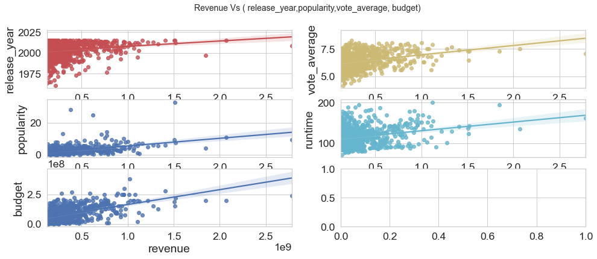

```python
#represent chart for revenue vs release_year,popularity,vote_average, budget
fig, axes = plt.subplots(3,2,figsize = (16,6))


sns.regplot(x=df_revenue['revenue'], y=df_revenue['release_year'],color='r',ax=axes[0][0])
sns.regplot(x=df_revenue['revenue'], y=df_revenue['vote_average'],color='y',ax=axes[0][1])
sns.regplot(x=df_revenue['revenue'], y=df_revenue['popularity'],color='b',ax=axes[1][0])
sns.regplot(x=df_revenue['revenue'], y=df_revenue['runtime'],color='c',ax=axes[1][1])
sns.regplot(x=df_revenue['revenue'], y=df_revenue['budget'],color='b',ax=axes[2][0])

fig.suptitle("Revenue Vs ( release_year,popularity,vote_average, budget)",fontsize=14)
sns.set_style("whitegrid")
```

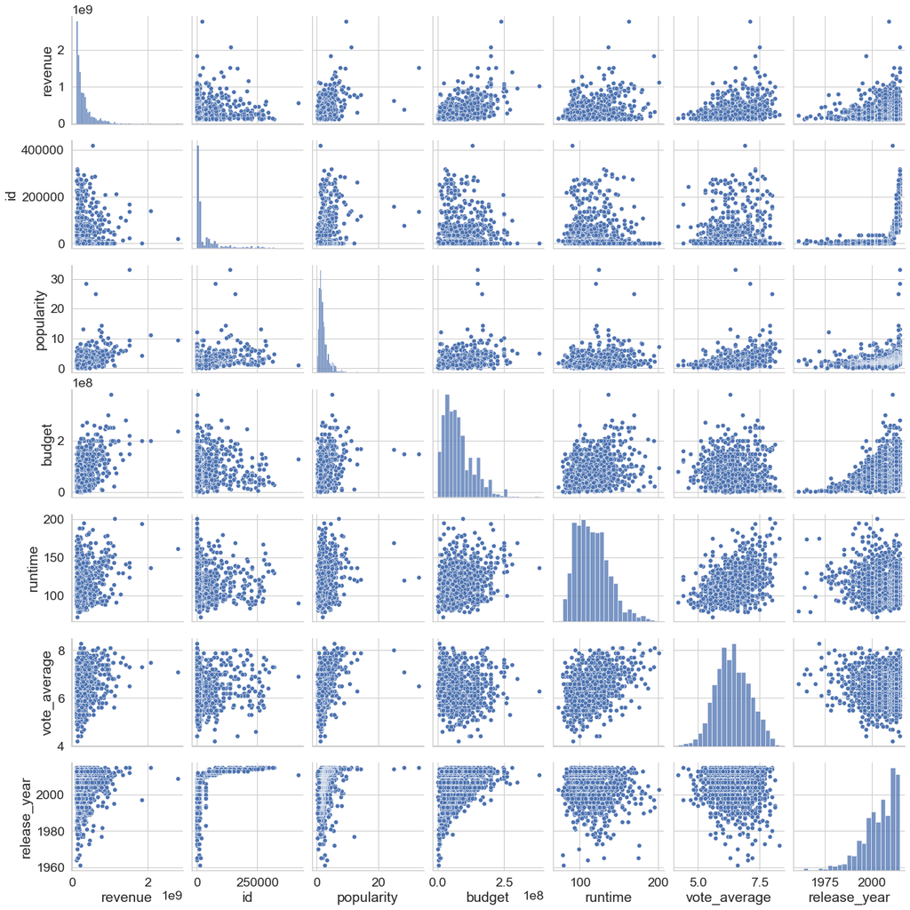

```python
sns.pairplot(df_revenue, kind="scatter")
plt.show()
fig.suptitle("Revenue Vs ( release_year,popularity,vote_average, budget)",fontsize=14)
sns.set_style("whitegrid")
```

```python
#function to calculat and draw coefficient-of-correlation
def pl_coor_map(df_revenue ):
    corr_map = df_revenue.corr()
    _ , axis = plt.subplots( figsize =( 18 , 10 ) )
    pl_map = sns.color_palette("ch:start=.2,rot=-.3", as_cmap=True)
    _ = sns.heatmap(corr_map,cmap = pl_map,square=True, cbar_kws={ 'shrink' : .9 }, ax=axis, annot = True, annot_kws = { 'fontsize' : 14 })
```

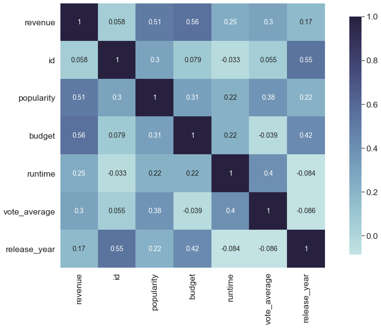

```python
pl_coor_map(df_revenue[['revenue','id','popularity','budget','runtime','vote_average','release_year']])
#https://stackoverflow.com/questions/65596029/seaborn-dont-give-color-in-heatmap-if-cell-value-is-higher-than-0-05
```

###### description for this plots,

in the first plot

###### where Budget vs Revenue

Revenue increases slightly at higher levels but the number of high-budget films appears to be rare. There is a good chance that movies with higher investment will lead to better returns.

###### vote average vs revenu

The relationship between them is very weak, and the revenu do not seem to change with a higher average revenu The correlation between them and vote average is 0.297.

###### Popularity vs Revenue

Revenue appears to increase with popularity. you can say that when a movie's popularity high, then the movie's revenue might be high

where the Correlation is 0.51

###### Runtime vs Revenue

The relationship between them is very weak, and the revenu do not seem to change with a higher average revenu The correlation between them and runtime is 0.2465

```python
#TTo see coefficient-of-correlation
rs = np.random.RandomState(0)
df = pd.DataFrame(rs.rand(10, 10))
corr = df_revenue.corr()
corr.style.background_gradient(cmap='coolwarm')

#https://stackoverflow.com/questions/29432629/plot-correlation-matrix-using-pandas
```

|  | revenue | id | popularity | budget | runtime | vote_average | release_year |
| --- | --- | --- | --- | --- | --- | --- | --- |
| revenue | 1.000000 | 0.057595 | 0.511673 | 0.557030 | 0.246599 | 0.297338 | 0.172144 |
| id | 0.057595 | 1.000000 | 0.297947 | 0.078678 | -0.033473 | 0.055437 | 0.545776 |
| popularity | 0.511673 | 0.297947 | 1.000000 | 0.313969 | 0.221397 | 0.380257 | 0.224221 |
| budget | 0.557030 | 0.078678 | 0.313969 | 1.000000 | 0.222530 | -0.038839 | 0.424115 |
| runtime | 0.246599 | -0.033473 | 0.221397 | 0.222530 | 1.000000 | 0.401609 | -0.084156 |
| vote_average | 0.297338 | 0.055437 | 0.380257 | -0.038839 | 0.401609 | 1.000000 | -0.086164 |
| release_year | 0.172144 | 0.545776 | 0.224221 | 0.424115 | -0.084156 | -0.086164 | 1.000000 |

# analysis from this charts

```python
#for column not appear in chart
df_frequent=df_revenue.mode()
df_frequent
```

|  | revenue | id | popularity | budget | runtime | vote_average | release_year | genres | director | cast |
| --- | --- | --- | --- | --- | --- | --- | --- | --- | --- | --- |
| 0 | 152000000.0 | 11 | 0.131526 | 40000000.0 | 115.0 | 6.1 | 2011.0 | Comedy | Steven Spielberg | Elijah Wood\|Ian McKellen\|Viggo Mortensen\|Liv T... |
| 1 | NaN | 12 | 0.142486 | NaN | NaN | NaN | NaN | NaN | NaN | Jennifer Lawrence\|Josh Hutcherson\|Liam Hemswor... |
| 2 | NaN | 13 | 0.155768 | NaN | NaN | NaN | NaN | NaN | NaN | NaN |
| 3 | NaN | 14 | 0.157586 | NaN | NaN | NaN | NaN | NaN | NaN | NaN |
| 4 | NaN | 18 | 0.164515 | NaN | NaN | NaN | NaN | NaN | NaN | NaN |
| ... | ... | ... | ... | ... | ... | ... | ... | ... | ... | ... |
| 959 | NaN | 294254 | 13.112507 | NaN | NaN | NaN | NaN | NaN | NaN | NaN |
| 960 | NaN | 296098 | 14.311205 | NaN | NaN | NaN | NaN | NaN | NaN | NaN |
| 961 | NaN | 312221 | 24.949134 | NaN | NaN | NaN | NaN | NaN | NaN | NaN |
| 962 | NaN | 318846 | 28.419936 | NaN | NaN | NaN | NaN | NaN | NaN | NaN |
| 963 | NaN | 417859 | 32.985763 | NaN | NaN | NaN | NaN | NaN | NaN | NaN |

964 rows × 10 columns

```python
n = 10
df_revenue['release_year'].value_counts()[:n].index.tolist()
```

```
[2011, 2014, 2013, 2012, 2010, 2015, 2008, 2007, 2009, 2003]
```

```python
df_revenue['runtime'].mean()
```

```
116.18879668049793
```

```python
df_revenue['genres'].value_counts().idxmax()
```

```
'Comedy'
```

```python
df_revenue['director'].value_counts().idxmax()
```

```
'Steven Spielberg'
```

```python
df_revenue['budget'].mean()
```

```
79037022.82572614
```

```python
#find freuqent_value for each columns
most_release_year= df_revenue["release_year"].value_counts().idxmax()
avg_runtime= df_revenue['runtime'].mean()
most_genres =df_revenue['genres'].value_counts().idxmax()
most_director =df_revenue['director'].value_counts().idxmax()
avg_budget= df_revenue['budget'].mean()
avg_vote = df_revenue['vote_average'].mean()
```

```python
#now  create dataframe to put value in it
df_associated_properties = pd.DataFrame({'release_year' : most_release_year,
                       'avg_runtime' : avg_runtime,
                         'frequent_genres' : most_genres,
                           'frequent_director' : most_director,
                         'avg_budget' : avg_budget,
                           'avg_vote' : avg_vote      ,
                      }.items(), columns=["property", "value of assoicate"])
df_associated_properties
```

|  | property | value of assoicate |
| --- | --- | --- |
| 0 | release_year | 2011 |
| 1 | avg_runtime | 116.189 |
| 2 | frequent_genres | Comedy |
| 3 | frequent_director | Steven Spielberg |
| 4 | avg_budget | 7.9037e+07 |
| 5 | avg_vote | 6.40218 |

##### Answer same addion questions

###### Question : avrage of revenues for the movies

```python
df2['revenue'].mean()
```

```
107686616.09807992
```

###### Question : mean Budget of the movies

```python
df2['budget'].mean()
```

```
37203696.954852104
```

###### Question most apperence cast

```python
df2[['cast']].mode()
```

|  | cast |
| --- | --- |
| 0 | William Shatner\|Leonard Nimoy\|DeForest Kelley\|... |

###### Question most genres whiched is

```python
 df2["genres"].value_counts().idxmax()
```

```
'Drama'
```

###### Question : best movies based on their popularity

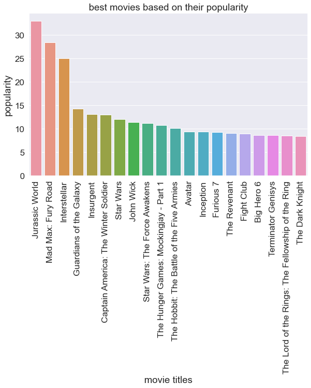

```python
sns.set(rc={'figure.figsize':(10,6)}, font_scale=1.6)
popularity_movies = df2[['original_title','popularity']]

pl = sns.barplot(
    popularity_movies .sort_values(by="popularity", ascending=False).head(20).original_title,
    popularity_movies .sort_values(by="popularity", ascending=False).head(20).popularity)



for i in pl.get_xticklabels():
    i.set_rotation(90)

pl.set(xlabel='movie titles', ylabel='popularity', title = 'best movies based on their popularity')
plt.show()
```

###### from this chart we can found that

the best movies in imbd based on their popularity is jurassic world than mad max fury road and interstellar

###### Question best movies based on their revenues

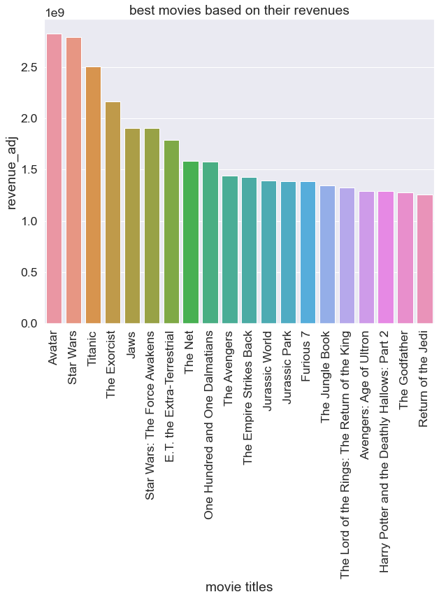

```python
sns.set(rc={'figure.figsize':(10,8)}, font_scale=1.6)
best_movie_revenues = df2[["original_title", "revenue_adj"]]

pl = sns.barplot(
    best_movie_revenues .sort_values(by="revenue_adj", ascending=False).head(20).original_title,
    best_movie_revenues .sort_values(by="revenue_adj", ascending=False).head(20).revenue_adj)



for i in pl.get_xticklabels():
    i.set_rotation(90)

pl.set(xlabel='movie titles', ylabel='revenue_adj', title = 'best movies based on their revenues')
plt.show()
```

###### from this chart we can found that

the best movies in imbd based on the revenu that make is avatar than star wars and titanic

## LIMITION

This dataset is very informative. This analysis was done with the understanding that this may not be completely error-free. Some of the limitations that the dataset has are null and zero values in some features. They should be removed from the rows Moreover, we are not sure if the data provided to us is completely correct and up-to-date. And also The Budget and Revenue column does not contain a currency unit, it may be possible for different movies to have a budget in different currency according to the country so there is a difference that could indicate an error in the complete analysis. But his year is clear to us from Data set . That we have a high probability of achieving high profits if we have characteristics similar to what was found in the analysis. If we release a movie with these characteristics

```python
from subprocess import call
call(['python', '-m', 'nbconvert', 'Investigate_a_Dataset.ipynb'])
```

```
1
```